# Le,Cody-DSC540-ProjectML

## Multiclass Learning Models

To further optimize model performance, multiclass learning meta-estimators models will be implemented. Multiclass methods provides support for multiclass prediction and custom multiclass strategies.  
**One-vs-Rest (OvR) Approach:** This multiclass approach fits one classifier per class and the class is fitted against all other classes.  
**One-vs-One (OvO) Approach:** This multiclass approach fits one classifier per class pair and at time of prediction, the class which received the most votes is selected.

### One-vs-Rest (OvR) Models

#### OvR Random Forest

```python
# Random Forest One-vs-Rest: Initialize Classifier
OvR_RF = OneVsRestClassifier(best_RF, n_jobs=-1)
```

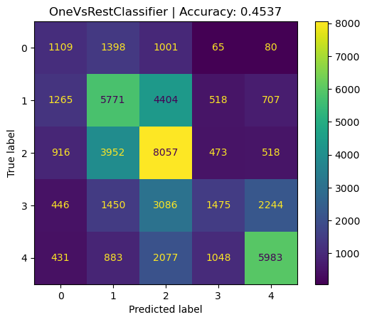

```
              precision    recall  f1-score   support

           0       0.27      0.30      0.28      3653
           1       0.43      0.46      0.44     12665
           2       0.43      0.58      0.50     13916
           3       0.41      0.17      0.24      8701
           4       0.63      0.57      0.60     10422

    accuracy                           0.45     49357
   macro avg       0.43      0.42      0.41     49357
weighted avg       0.46      0.45      0.44     49357
```

```python
# View Accuracy, Confusion Matrix, and Performance
OvR_RF_val = fit_predict_score(OvR_RF, X2n_train, y_train, X2n_val, y_val) # get scores as DF
fit_predict_display_scores(OvR_RF, X2n_train, y_train, X2n_val, y_val) # display  confusion matrix + score
```

Above, the OvR Random Forest model achieved a validation accuracy of **0.4537**, which is an improvement from the previous optimized Random Forest model. This model slightly improved predictions for class 1 and 2, although it did not improve predictions for class 0 or 3.

#### OvR AdaBoost

```python
# Adaboost One-vs-Rest: Initialize Classifier
OvR_ada = OneVsRestClassifier(best_ada, n_jobs=-1)
```

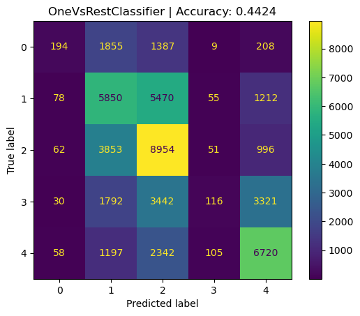

```
              precision    recall  f1-score   support

           0       0.46      0.05      0.10      3653
           1       0.40      0.46      0.43     12665
           2       0.41      0.64      0.50     13916
           3       0.35      0.01      0.03      8701
           4       0.54      0.64      0.59     10422

    accuracy                           0.44     49357
   macro avg       0.43      0.36      0.33     49357
weighted avg       0.43      0.44      0.39     49357
```

```python
# View Accuracy, Confusion Matrix, and Performance
OvR_ada_val = fit_predict_score(OvR_ada, X2n_train, y_train, X2n_val, y_val) # get scores as DF
fit_predict_display_scores(OvR_ada, X2n_train, y_train, X2n_val, y_val) # display  confusion matrix + score
```

Above, the OvR AdaBoost model achieved a validation accuracy of **0.4424**, which is an improvement from the previous optimized AdaBoost model. This model slighly improved its predication and f1 score for class 0.

#### OvR HistGradient Boost

```python
# Histogram-Based Gradient Boost One-vs-Rest: Initialize Classifier
OvR_hgbst = OneVsRestClassifier(best_hgbst, n_jobs=-1)
```

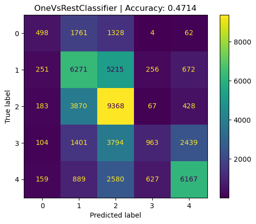

```
              precision    recall  f1-score   support

           0       0.42      0.14      0.21      3653
           1       0.44      0.50      0.47     12665
           2       0.42      0.67      0.52     13916
           3       0.50      0.11      0.18      8701
           4       0.63      0.59      0.61     10422

    accuracy                           0.47     49357
   macro avg       0.48      0.40      0.40     49357
weighted avg       0.48      0.47      0.44     49357
```

```python
# View Accuracy, Confusion Matrix, and Performance
OvR_hgbst_val = fit_predict_score(OvR_hgbst, X2n_train, y_train, X2n_val, y_val) # get scores as DF
fit_predict_display_scores(OvR_hgbst, X2n_train, y_train, X2n_val, y_val) # display  confusion matrix + score
```

Above, the OvR Histogram-Based Gradient Boosting model achieved a validation accuracy of **0.4714**, which is a lower accuracy score than the previous optimized Histogram-Based Gradient Boosting model. Moreover, the One-vs-Rest strategy did not improve the performance for classifier.

#### OvR Linear Discrimiant Analysis (LDA)

```python
# LDA One-vs-Rest: Initialize Classifier
OvR_lda = OneVsRestClassifier(lda, n_jobs=-1)
```

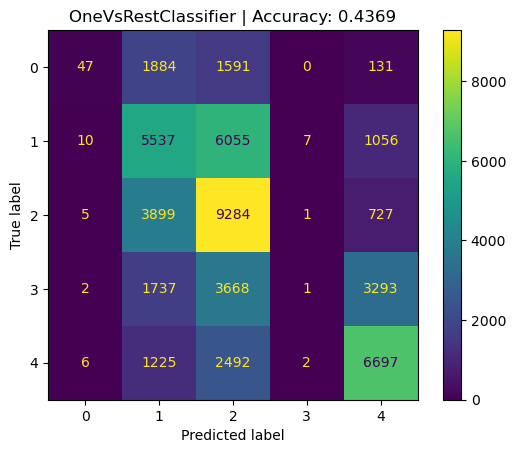

```
              precision    recall  f1-score   support

           0       0.67      0.01      0.03      3653
           1       0.39      0.44      0.41     12665
           2       0.40      0.67      0.50     13916
           3       0.09      0.00      0.00      8701
           4       0.56      0.64      0.60     10422

    accuracy                           0.44     49357
   macro avg       0.42      0.35      0.31     49357
weighted avg       0.40      0.44      0.38     49357
```

```python
# View Accuracy, Confusion Matrix, and Performance
OvR_lda_val = fit_predict_score(OvR_lda, X2n_train, y_train, X2n_val, y_val) # get scores as DF
fit_predict_display_scores(OvR_lda, X2n_train, y_train, X2n_val, y_val) # display  confusion matrix + score
```

Above, the OvR LDA model achieved a validation accuracy of **0.4369**, which is a lower accuracy score than the baseline LDA model. Moreover, the One-vs-Rest strategy did not improve the performance for the LDA classifier.

### One-vs-One (OvO) Models

#### OvO Random Forest

```python
# Random Forest One-vs-One: Initialize Classifier
OvO_RF = OneVsOneClassifier(best_RF, n_jobs=-1)
```

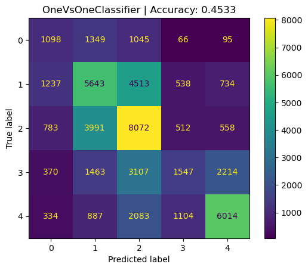

```
              precision    recall  f1-score   support

           0       0.29      0.30      0.29      3653
           1       0.42      0.45      0.43     12665
           2       0.43      0.58      0.49     13916
           3       0.41      0.18      0.25      8701
           4       0.63      0.58      0.60     10422

    accuracy                           0.45     49357
   macro avg       0.44      0.42      0.41     49357
weighted avg       0.46      0.45      0.44     49357
```

```python
# View Accuracy, Confusion Matrix, and Performance
OvO_RF_val = fit_predict_score(OvO_RF, X2n_train, y_train, X2n_val, y_val) # get scores as DF
fit_predict_display_scores(OvO_RF, X2n_train, y_train, X2n_val, y_val) # display  confusion matrix + score
```

#### OvO AdaBoost

```python
# Adaboost One-vs-One: Initialize Classifier
OvO_ada = OneVsOneClassifier(best_ada, n_jobs=-1)
```

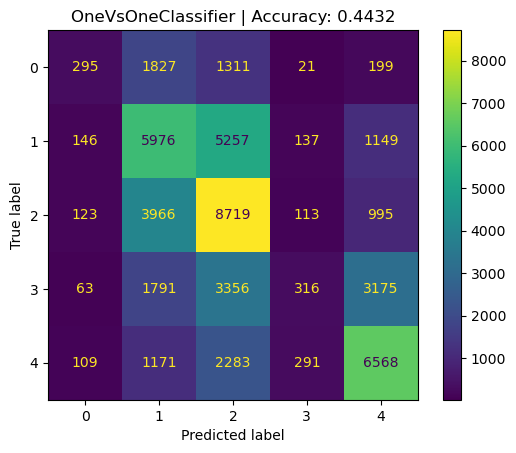

```
              precision    recall  f1-score   support

           0       0.40      0.08      0.13      3653
           1       0.41      0.47      0.44     12665
           2       0.42      0.63      0.50     13916
           3       0.36      0.04      0.07      8701
           4       0.54      0.63      0.58     10422

    accuracy                           0.44     49357
   macro avg       0.43      0.37      0.34     49357
weighted avg       0.43      0.44      0.40     49357
```

```python
# View Accuracy, Confusion Matrix, and Performance
OvO_ada_val = fit_predict_score(OvO_ada, X2n_train, y_train, X2n_val, y_val) # get scores as DF
fit_predict_display_scores(OvO_ada, X2n_train, y_train, X2n_val, y_val) # display  confusion matrix + score
```

Above, the OvO AdaBoost model achieved a validation accuracy of **0.4432**, which is similar but slight improvement from the OvR AdaBoost model. This model improves its predication and f1 score for class 0 compared to the OvR AdaBoost model.

#### OvO HistGradient Boost

```python
# Histogram-Based Gradient Boost One-vs-One: Initialize Classifier
OvO_hgbst = OneVsOneClassifier(best_hgbst, n_jobs=-1)
```

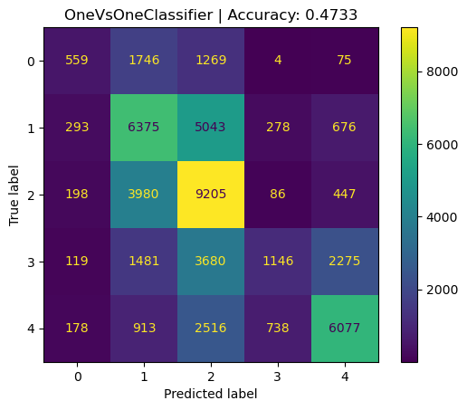

```
              precision    recall  f1-score   support

           0       0.41      0.15      0.22      3653
           1       0.44      0.50      0.47     12665
           2       0.42      0.66      0.52     13916
           3       0.51      0.13      0.21      8701
           4       0.64      0.58      0.61     10422

    accuracy                           0.47     49357
   macro avg       0.48      0.41      0.41     49357
weighted avg       0.49      0.47      0.45     49357
```

```python
# View Accuracy, Confusion Matrix, and Performance
OvO_hgbst_val = fit_predict_score(OvO_hgbst, X2n_train, y_train, X2n_val, y_val) # get scores as DF
fit_predict_display_scores(OvO_hgbst, X2n_train, y_train, X2n_val, y_val) # display  confusion matrix + score
```

Above, the OvO Histogram-Based Gradient Boosting model achieved a validation accuracy of **0.4733**, which is a slight improvement over the previous optimized Histogram-Based Gradient Boosting model and better than the OvR model. This model slightly improved in predictions and f1 score for class 3.

#### OvO Linear Discrimiant Analysis (LDA)

```python
# LDA One-vs-One: Initialize Classifier
OvO_lda = OneVsOneClassifier(lda, n_jobs=-1)
```

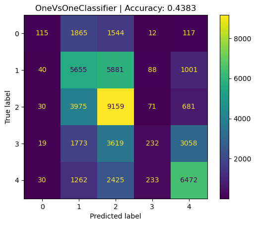

```
              precision    recall  f1-score   support

           0       0.49      0.03      0.06      3653
           1       0.39      0.45      0.42     12665
           2       0.40      0.66      0.50     13916
           3       0.36      0.03      0.05      8701
           4       0.57      0.62      0.60     10422

    accuracy                           0.44     49357
   macro avg       0.44      0.36      0.32     49357
weighted avg       0.44      0.44      0.39     49357
```

```python
# View Accuracy, Confusion Matrix, and Performance
OvO_lda_val = fit_predict_score(OvO_lda, X2n_train, y_train, X2n_val, y_val) # get scores as DF
fit_predict_display_scores(OvO_lda, X2n_train, y_train, X2n_val, y_val) # display  confusion matrix + score
```

Above, the OvO LDA model achieved a validation accuracy of **0.4383**, which is a slight improvement over the previous baseline LDA model and better than the OvR LDA model. This model slightly improved in predictions and f1 score for class 0 and 1 compared to the baseline LDA model.

### Results Summary for OvR & OvO Models

```python
# Display Accuracy Results for OvR & OvO Models
OvROvO_df = [OvR_lda_val, OvO_lda_val, OvO_ada_val, OvR_ada_val, OvO_RF_val, OvR_RF_val,
             OvR_hgbst_val, OvO_hgbst_val]
OvROvO_results = pd.concat(OvROvO_df, ignore_index=True) #combine all model results
OvROvO_results.loc[[0], ['Model']] = 'One-vs-Rest(OvR)-LDA' #rename model
OvROvO_results.loc[[1], ['Model']] = 'One-vs-One(OvO)-LDA' #rename model
OvROvO_results.loc[[2], ['Model']] = 'One-vs-One(OvO)-AdaBoost' #rename model
OvROvO_results.loc[[3], ['Model']] = 'One-vs-Rest(OvR)-AdaBoost' #rename model
OvROvO_results.loc[[4], ['Model']] = 'One-vs-One(OvO)-RandomForest' #rename model
OvROvO_results.loc[[5], ['Model']] = 'One-vs-Rest(OvR)-RandomForest' #rename model
OvROvO_results.loc[[6], ['Model']] = 'One-vs-Rest(OvR)-HistGradientBoost' #rename model
OvROvO_results.loc[[7], ['Model']] = 'One-vs-One(OvO)-HistGradientBoost' #rename model
OvROvO_results
```

|  | Model | Accuracy | Balanced Accuracy |
| --- | --- | --- | --- |
| 0 | One-vs-Rest(OvR)-LDA | 0.4369 | 0.3520 |
| 1 | One-vs-One(OvO)-LDA | 0.4383 | 0.3568 |
| 2 | One-vs-One(OvO)-AdaBoost | 0.4432 | 0.3691 |
| 3 | One-vs-Rest(OvR)-AdaBoost | 0.4424 | 0.3633 |
| 4 | One-vs-One(OvO)-RandomForest | 0.4533 | 0.4162 |
| 5 | One-vs-Rest(OvR)-RandomForest | 0.4537 | 0.4164 |
| 6 | One-vs-Rest(OvR)-HistGradientBoost | 0.4714 | 0.4014 |
| 7 | One-vs-One(OvO)-HistGradientBoost | 0.4733 | 0.4065 |

## Voting Ensemble Models

Voting ensemble models train on an ensemble of various models and predicts the class based on their highest probability of chosen class as the output. By aggregating the previous optimized models, a single voting model can be fitted and predict the output based on combined majority of the voting for each output class.

### Ensemble with Optimized Models

#### With Hard Voting

```python
# Initialize VotingClassifier with best estimators for RF, HistGradientBoost, AdaBoost
vote_clf1 = VotingClassifier(estimators=[('RF', best_RF), ('HistGBoost', best_hgbst),
                                        ('AdaBoost', best_ada)], voting='hard') #vote = hard
```

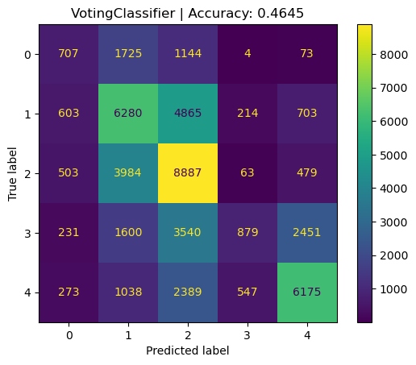

```
              precision    recall  f1-score   support

           0       0.31      0.19      0.24      3653
           1       0.43      0.50      0.46     12665
           2       0.43      0.64      0.51     13916
           3       0.51      0.10      0.17      8701
           4       0.62      0.59      0.61     10422

    accuracy                           0.46     49357
   macro avg       0.46      0.40      0.40     49357
weighted avg       0.48      0.46      0.44     49357
```

```python
# View Accuracy, Confusion Matrix, and Performance
vote1_val = fit_predict_score(vote_clf1, X2n_train, y_train, X2n_val, y_val) # get scores as DF
fit_predict_display_scores(vote_clf1, X2n_train, y_train, X2n_val, y_val) # display  confusion matrix + score
```

#### With Soft Voting

```python
# Initialize VotingClassifier with best estimators for RF, HistGradientBoost, & AdaBoost
vote_clf2 = VotingClassifier(estimators=[('RF', best_RF), ('HistGBoost', best_hgbst),
                                        ('AdaBoost', best_ada)], voting='soft') #vote = soft
```

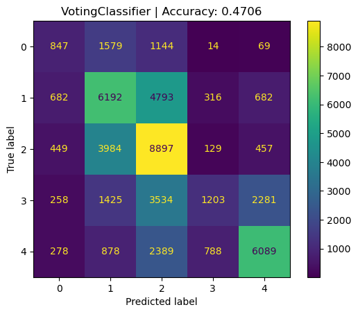

```
              precision    recall  f1-score   support

           0       0.34      0.23      0.27      3653
           1       0.44      0.49      0.46     12665
           2       0.43      0.64      0.51     13916
           3       0.49      0.14      0.22      8701
           4       0.64      0.58      0.61     10422

    accuracy                           0.47     49357
   macro avg       0.47      0.42      0.42     49357
weighted avg       0.48      0.47      0.45     49357
```

```python
# View Accuracy, Confusion Matrix, and Performance
vote2_val = fit_predict_score(vote_clf2, X2n_train, y_train, X2n_val, y_val) # get scores as DF
fit_predict_display_scores(vote_clf2, X2n_train, y_train, X2n_val, y_val) # display  confusion matrix + score
```

Above, the Voting Classifier with soft voting achieved better performance than with hard voting using the optimized Random Forest, HistGradient Boost, and AdaBoost models. The validation accuracy score for the hard voting model is **0.4645** whereas the accuracy score for the soft voting model is **0.4706**. In particular, the soft voting model has higher f1 scores and predicts class 0 and class 3 better than the hard voting model. Prior to this soft voting model, only the Histogram-Based Gradient Boost models have achieved an accuracy score above 0.47. MOreover, the Voting Classifier with soft voting is an improvement over the Random Forest and AdaBoost models.

### Ensemble with OvR & OvO Models

#### OvR With Hard Voting

```python
# Initialize VotingClassifier with OvR Models
vote_clf3 = VotingClassifier(estimators=[('OvR-RF', OvR_RF), ('OvR-HistGBoost', OvR_hgbst),
                                        ('OvR-AdaBoost', OvR_ada)], voting='hard') #vote = hard
```

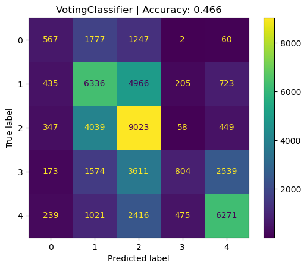

```
              precision    recall  f1-score   support

           0       0.32      0.16      0.21      3653
           1       0.43      0.50      0.46     12665
           2       0.42      0.65      0.51     13916
           3       0.52      0.09      0.16      8701
           4       0.62      0.60      0.61     10422

    accuracy                           0.47     49357
   macro avg       0.46      0.40      0.39     49357
weighted avg       0.48      0.47      0.44     49357
```

```python
# View Accuracy, Confusion Matrix, and Performance
vote3_val = fit_predict_score(vote_clf3, X2n_train, y_train, X2n_val, y_val) # get scores as DF
fit_predict_display_scores(vote_clf3, X2n_train, y_train, X2n_val, y_val) # display  confusion matrix + score
```

#### OvR with Soft Voting

```python
# Initialize VotingClassifier with OvR Models
vote_clf4 = VotingClassifier(estimators=[('OvR-RF', OvR_RF), ('OvR-HistGBoost', OvR_hgbst),
                                        ('OvR-AdaBoost', OvR_ada)], voting='soft') #vote = soft
```

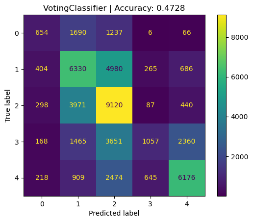

```
              precision    recall  f1-score   support

           0       0.38      0.18      0.24      3653
           1       0.44      0.50      0.47     12665
           2       0.42      0.66      0.52     13916
           3       0.51      0.12      0.20      8701
           4       0.63      0.59      0.61     10422

    accuracy                           0.47     49357
   macro avg       0.48      0.41      0.41     49357
weighted avg       0.49      0.47      0.45     49357
```

```python
# View Accuracy, Confusion Matrix, and Performance
vote4_val = fit_predict_score(vote_clf4, X2n_train, y_train, X2n_val, y_val) # get scores as DF
fit_predict_display_scores(vote_clf4, X2n_train, y_train, X2n_val, y_val) # display  confusion matrix + score
```

#### OvO With Hard Voting

```python
# Initialize VotingClassifier with OvO Models
vote_clf5 = VotingClassifier(estimators=[('OvO-RF', OvO_RF), ('OvO-HistGBoost', OvO_hgbst),
                                        ('OvO-AdaBoost', OvO_ada)], voting='hard') #vote = hard
```

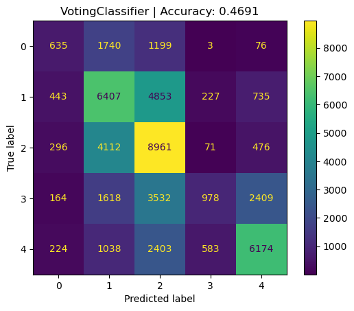

```
              precision    recall  f1-score   support

           0       0.36      0.17      0.23      3653
           1       0.43      0.51      0.46     12665
           2       0.43      0.64      0.51     13916
           3       0.53      0.11      0.19      8701
           4       0.63      0.59      0.61     10422

    accuracy                           0.47     49357
   macro avg       0.47      0.41      0.40     49357
weighted avg       0.48      0.47      0.44     49357
```

```python
# View Accuracy, Confusion Matrix, and Performance
vote5_val = fit_predict_score(vote_clf5, X2n_train, y_train, X2n_val, y_val) # get scores as DF
fit_predict_display_scores(vote_clf5, X2n_train, y_train, X2n_val, y_val) # display  confusion matrix + score
```

### Results Summary for Voting Ensembles

```python
# Display Accuracy Results for Voting Ensembles
vote_df = [vote1_val, vote3_val, vote5_val, vote2_val, vote4_val]
vote_results = pd.concat(vote_df, ignore_index=True) #combine all model results
vote_results.loc[[0], ['Model']] = 'VotingClassifier-Optimized Models w/ Hard Vote' #rename model
vote_results.loc[[1], ['Model']] = 'VotingClassifier-OvR w/ Hard Vote' #rename model
vote_results.loc[[2], ['Model']] = 'VotingClassifier-OvO w/ Hard Vote' #rename model
vote_results.loc[[3], ['Model']] = 'VotingClassifier-Optimized Models w/ Soft Vote' #rename model
vote_results.loc[[4], ['Model']] = 'VotingClassifier-OvR w/ Soft Vote' #rename model
vote_results
```

|  | Model | Accuracy | Balanced Accuracy |
| --- | --- | --- | --- |
| 0 | VotingClassifier-Optimized Models w/ Hard Vote | 0.4645 | 0.4043 |
| 1 | VotingClassifier-OvR w/ Hard Vote | 0.4660 | 0.3996 |
| 2 | VotingClassifier-OvO w/ Hard Vote | 0.4691 | 0.4057 |
| 3 | VotingClassifier-Optimized Models w/ Soft Vote | 0.4706 | 0.4165 |
| 4 | VotingClassifier-OvR w/ Soft Vote | 0.4728 | 0.4097 |

With the Voting Ensemble models, the models using soft voting performed better than the models using hard voting. The Voting Classifier with the One-to-Rest models (RandomForest, HistGradient Boost, and AdaBoost) with soft voting achieved the highest validation accuracy score at **0.4728**. The second highest performing model is the Voting ensemble using the optimized models with soft voting which achieved a similar but slightly lower accuracy score of **0.4706**. However, this model achieved the highest balanced accuracy score at **0.4165** compared to all other models.

## Model Evaluation on Test Set

With optimization, multiclass learning models, and voting ensemble models, the best performing models achieved accuracy scores of around **0.47**. The best performing models will be evaluated on the test set for final evaluation. The best optimized model is Histogram-Based Boosting Classifier, which is also used as the base estimator for the One-to-Rest (OvR) and One-to-One (OvO) Classifiers. The best voting classifiers included one ensemble with optimized Random Forest, Histogram-Based Gradient Boost, and AdaBoost using soft voting and another ensemble with OvR Random Forest, Histogram-Based Gradient Boost, and AdaBoost using soft voting.

### Models with Highest Performance

```python
# Display Classifier Models with Highest Accuracy
best_df = [vote2_val, OvR_hgbst_val, vote4_val, best_hgbst_val, OvO_hgbst_val]
best_results = pd.concat(best_df, ignore_index=True) #combine all model results
best_results.loc[[0], ['Model']] = 'VotingClassifier-Optimized Models w/ Soft Vote' #rename model
best_results.loc[[1], ['Model']] = 'One-vs-Rest(OvR)-HistGradientBoost' #rename model
best_results.loc[[2], ['Model']] = 'VotingClassifier-OvR w/ Soft Vote' #rename model
best_results.loc[[3], ['Model']] = 'HistGradientBoostingClassifier' #rename model
best_results.loc[[4], ['Model']] = 'One-vs-One(OvO)-HistGradientBoost' #rename model
best_results
```

|  | Model | Accuracy | Balanced Accuracy |
| --- | --- | --- | --- |
| 0 | VotingClassifier-Optimized Models w/ Soft Vote | 0.4706 | 0.4165 |
| 1 | One-vs-Rest(OvR)-HistGradientBoost | 0.4714 | 0.4014 |
| 2 | VotingClassifier-OvR w/ Soft Vote | 0.4728 | 0.4097 |
| 3 | HistGradientBoostingClassifier | 0.4728 | 0.4059 |
| 4 | One-vs-One(OvO)-HistGradientBoost | 0.4733 | 0.4065 |

### Voting Ensemble with Optimized Models

```python
# View Classifier w/ Models & Soft Voting
vote_clf2
```

```
VotingClassifier(estimators=[('RF',
                              RandomForestClassifier(class_weight='balanced',
                                                     max_depth=19,
                                                     random_state=0)),
                             ('HistGBoost',
                              HistGradientBoostingClassifier(learning_rate=0.09,
                                                             random_state=0)),
                             ('AdaBoost',
                              AdaBoostClassifier(learning_rate=0.7,
                                                 random_state=0))],
                 voting='soft')
```

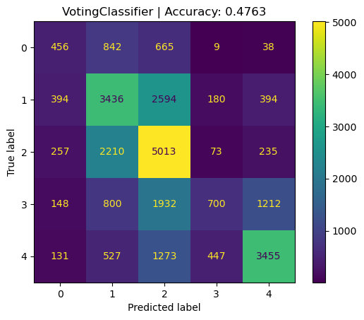

```
              precision    recall  f1-score   support

           0       0.33      0.23      0.27      2010
           1       0.44      0.49      0.46      6998
           2       0.44      0.64      0.52      7788
           3       0.50      0.15      0.23      4792
           4       0.65      0.59      0.62      5833

    accuracy                           0.48     27421
   macro avg       0.47      0.42      0.42     27421
weighted avg       0.48      0.48      0.46     27421
```

```python
# Fit, Predict on Test Set and View Performance
vote_test = fit_predict_score(vote_clf2, X2n_train, y_train, X2n_test, y_test) # get scores as DF
fit_predict_display_scores(vote_clf2, X2n_train, y_train, X2n_test, y_test) # display confusion matrix + score
```

### One-vs-Rest (OvR) - Histogram-Based Gradient Boost

```python
# View Classifier
OvR_hgbst
```

```
OneVsRestClassifier(estimator=HistGradientBoostingClassifier(learning_rate=0.09,
                                                             random_state=0),
                    n_jobs=-1)
```

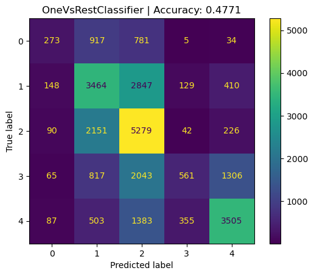

```
              precision    recall  f1-score   support

           0       0.41      0.14      0.20      2010
           1       0.44      0.49      0.47      6998
           2       0.43      0.68      0.52      7788
           3       0.51      0.12      0.19      4792
           4       0.64      0.60      0.62      5833

    accuracy                           0.48     27421
   macro avg       0.49      0.41      0.40     27421
weighted avg       0.49      0.48      0.45     27421
```

```python
# Fit, Predict on Test Set and View Performance
OvR_hgbst_test = fit_predict_score(OvR_hgbst, X2n_train, y_train, X2n_test, y_test) # get scores as DF
fit_predict_display_scores(OvR_hgbst, X2n_train, y_train, X2n_test, y_test) # display confusion matrix + score
```

The One-vs-Rest Classifier with Histogram-Based Gradient Boost as the base estimator achieved an accuracy score of **0.4771** on the testing set, which is better than the results from the validation set. The model in particular has a slightly higher f1 score for class 3 and 4 on the testing set compared to the validation set.

### Voting Ensemble with One-vs-Rest Models

```python
# View Classifier w/ Models & Soft Voting
vote_clf4
```

```
VotingClassifier(estimators=[('OvR-RF',
                              OneVsRestClassifier(estimator=RandomForestClassifier(class_weight='balanced',
                                                                                   max_depth=19,
                                                                                   random_state=0),
                                                  n_jobs=-1)),
                             ('OvR-HistGBoost',
                              OneVsRestClassifier(estimator=HistGradientBoostingClassifier(learning_rate=0.09,
                                                                                           random_state=0),
                                                  n_jobs=-1)),
                             ('OvR-AdaBoost',
                              OneVsRestClassifier(estimator=AdaBoostClassifier(learning_rate=0.7,
                                                                               random_state=0),
                                                  n_jobs=-1))],
                 voting='soft')
```

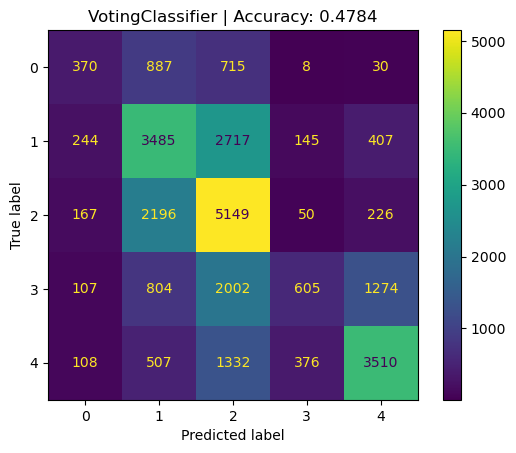

```
              precision    recall  f1-score   support

           0       0.37      0.18      0.25      2010
           1       0.44      0.50      0.47      6998
           2       0.43      0.66      0.52      7788
           3       0.51      0.13      0.20      4792
           4       0.64      0.60      0.62      5833

    accuracy                           0.48     27421
   macro avg       0.48      0.41      0.41     27421
weighted avg       0.49      0.48      0.45     27421
```

```python
vote_OvR_test = fit_predict_score(vote_clf4, X2n_train, y_train, X2n_test, y_test) # get scores as DF
fit_predict_display_scores(vote_clf4, X2n_train, y_train, X2n_test, y_test) # display confusion matrix + score
```

The Voting Classifier with One-vs-Rest (OvR) models and soft voting achieved an accuracy score of **0.4784** on the testing set, which is better than the results from the validation set. The model in particular has a higher f1 score for class 0 and 4 on the testing set compared to the validation set.

### Histogram-Based Gradient Boosting

```python
# View Classifier w/ Optimized Parameters
best_hgbst
```

```
HistGradientBoostingClassifier(learning_rate=0.09, random_state=0)
```

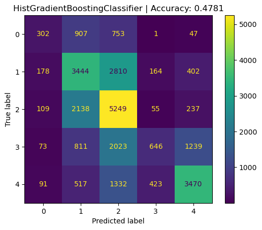

```
              precision    recall  f1-score   support

           0       0.40      0.15      0.22      2010
           1       0.44      0.49      0.46      6998
           2       0.43      0.67      0.53      7788
           3       0.50      0.13      0.21      4792
           4       0.64      0.59      0.62      5833

    accuracy                           0.48     27421
   macro avg       0.48      0.41      0.41     27421
weighted avg       0.49      0.48      0.45     27421
```

```python
# Fit, Predict on Test Set and View Performance
best_hgbst_test = fit_predict_score(best_hgbst, X2n_train, y_train, X2n_test, y_test) # get scores as DF
fit_predict_display_scores(best_hgbst, X2n_train, y_train, X2n_test, y_test) # display confusion matrix + score
```

The Histogram-Based Gradient Boosting model with optimized parameters achieved an accuracy score of **0.4781** on the testing set, which is slightly better than the results from the validation set. This model in particular has a higher f1 score for class 3 and 4 on the testing set compared to the validation set.

### One-vs-One (OvO) - Histogram Gradient Boost

```python
# View Classifier
OvO_hgbst
```

```
OneVsOneClassifier(estimator=HistGradientBoostingClassifier(learning_rate=0.09,
                                                            random_state=0),
                   n_jobs=-1)
```

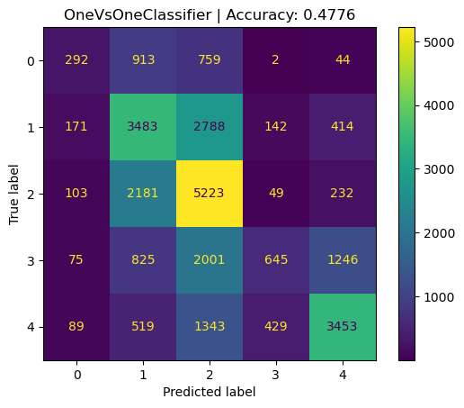

```
              precision    recall  f1-score   support

           0       0.40      0.15      0.21      2010
           1       0.44      0.50      0.47      6998
           2       0.43      0.67      0.52      7788
           3       0.51      0.13      0.21      4792
           4       0.64      0.59      0.62      5833

    accuracy                           0.48     27421
   macro avg       0.48      0.41      0.41     27421
weighted avg       0.49      0.48      0.45     27421
```

```python
# Fit, Predict on Test Set and View Performance
OvO_hgbst_test = fit_predict_score(OvO_hgbst, X2n_train, y_train, X2n_test, y_test) # get scores as DF
fit_predict_display_scores(OvO_hgbst, X2n_train, y_train, X2n_test, y_test) # display confusion matrix + score
```

The One-vs-One Classifier with Histogram-Based Gradient Boost as the base estimator achieved an accuracy score of **0.4776** on the testing set, which is better than the results from the validation set. This model is comparable to the One-vs-Rest Classiifer with Histogram-Based Gradient Boost and achieves a slightly higher testing accuracy.

## Final Results and Best Model

```python
# Display Final Results from Testing Evaluation
final_df = [vote2_val, vote_test, OvR_hgbst_val, OvR_hgbst_test,
            OvO_hgbst_val, OvO_hgbst_test, best_hgbst_val, best_hgbst_test, vote4_val, vote_OvR_test]
final_results = pd.concat(final_df, ignore_index=True) #combine all model results
final_results.loc[[0, 1], ['Model']] = 'VotingClassifier-Optimized Models w/ Soft Vote' #rename model
final_results.loc[[2, 3], ['Model']] = 'One-vs-Rest(OvR)-HistGradientBoost' #rename model
final_results.loc[[4, 5], ['Model']] = 'One-vs-One(OvO)-HistGradientBoost' #rename model
final_results.loc[[6, 7], ['Model']] = 'HistGradientBoostingClassifier' #rename model
final_results.loc[[8, 9], ['Model']] = 'VotingClassifier-OvR w/ Soft Vote' #rename model
final_results.rename(index={0: 'Validation', 1: 'Testing', 2: 'Validation', 3: 'Testing',
                            4: 'Validation', 5: 'Testing', 6: 'Validation', 7: 'Testing',
                            8: 'Validation', 9: 'Testing'}) #rename df index
```

|  | Model | Accuracy | Balanced Accuracy |
| --- | --- | --- | --- |
| Validation | VotingClassifier-Optimized Models w/ Soft Vote | 0.4706 | 0.4165 |
| Testing | VotingClassifier-Optimized Models w/ Soft Vote | 0.4763 | 0.4200 |
| Validation | One-vs-Rest(OvR)-HistGradientBoost | 0.4714 | 0.4014 |
| Testing | One-vs-Rest(OvR)-HistGradientBoost | 0.4771 | 0.4053 |
| Validation | One-vs-One(OvO)-HistGradientBoost | 0.4733 | 0.4065 |
| Testing | One-vs-One(OvO)-HistGradientBoost | 0.4776 | 0.4080 |
| Validation | HistGradientBoostingClassifier | 0.4728 | 0.4059 |
| Testing | HistGradientBoostingClassifier | 0.4781 | 0.4092 |
| Validation | VotingClassifier-OvR w/ Soft Vote | 0.4728 | 0.4097 |
| Testing | VotingClassifier-OvR w/ Soft Vote | 0.4784 | 0.4142 |

The Voting Classifier with One-vs-Rest models (Random Forest, Histogram-Based Gradient Boost, and AdaBoost) with soft voting achieved the highest accuracy score on the test set at **0.4784**. This accuracy score is slightly higher than the validation accuracy score of **0.4728**. Moreover, the voting ensemble approach sucessfully took three tree models and outputted a model that performed better than all other models. The Runner Up model goes to the optimized Histogram Gradient Boosting Classifier model which achieved a testing accuracy of **0.4781**, which is very close to the same score achieved by the best model. This model is faster and more efficient and is a more simplied model is preferred, than this model would be preferred over the best model. The model that achieved the highest balanced accuracy is the Voting Classifier with optimized models with soft voting which achieved a balanced accuracy score of **0.42**.

## Discussion and Future Work

### Discussion

Although the voting ensemble and the multiclass methods (including One-vs-Rest and One-vs-One) improved model performance and the resulting final models have higher accuracies than the baseline models, unforunately, the best model only achieved a testing accuracy of **0.4784**. This means that the models are not well fit to the data and unable to predict the target variable, Stay Days. Nevertheless, the model performance here is an improvement in model performance over the models presented by Jianing Pei et al. which analyzed the same dataset. Their analysis and findings were based on the original target variable having 9 classes, instead of combining the classes to become 5 classes as done in this analysis. Their suggestion for future analysis was to reduce the number of target classes to focus on Stay Days with 40 days or less. Moreover, this analysis has implemented their suggestion by creating the 41+ days class and condensing the target class to 5. The best model by Jianing Pei et al. achieved an accuracy score of 0.3541. Here, with the optimization methods implemented and with the voting ensemble, the final models performed better with accuracy scores above 0.47.

There are several reasons that may be preventing the models from achieving higher performance. First, the dataset contains mostly categorical features with very few numeric features. The two main numeric features, Patient Visitors and Admission Deposit, ended up being the most salient features for the models as shown in the feature importance plots. With many categorical features, the number of dummy features is quite high which may affect model performance. Most importantly, the main reason the models may be unable to predict the target is because of the imbalance of the dataset. Throughout all of the models, the f1 scores were very low for class 0 and class 3. Class 0, which represents Stay Days 0-10, had significantly less instances than Class 1, 2, and 4. When there is a high imbalance of instances, especially in the target variable, it becomes more challenging for the algorithm to learn and predict. In addition, the data is also skewed in terms of distribution of features, with many of the features not following a normal distribution. In particular, for Department, there is over 78% of the instances from one department, Gynecology, out of 5 departments. Moreover, the imbalance of the dataset is likely the main factor to model performance.

### Future Analysis

If given more time, further work on the dataset can be explored to improve model performance. First, since the dataset is quite large but since 78% of the data belongs to one Department, Gynecology, instead of analyzing the entire dataset, an analysis of a subset of the data, focusing only on the Gynecology department can be explored. This will reduce the number of features and potentially make the dataset more balanced. In addition, Ward Type has very little instances in 2 out of 5 categories, either drop the instances so that Ward Type only has 3 categories, or drop the feature altogether. From the feature importance plot from the Gradient Boosting Classifier, Ward_Type and Ward_Facility are not important features and thus, can be dropped. Next, for the target variable, class 0, which represents 0-10 days has too few instances, in future analysis, the target variable can be transformed so that the classes are combined as following: 0-10 days with 10-20 days = 0-20 days (class 0), 21-30 days (class 1), 31-40 days (class 2), and 41+ days (class 3). By condensing the target variable further to 4 classes, the class imbalance may be resolved and the models may be better able to predict the target variable based on the features. Lastly, additional feature selection can be performed prior to model training. Using the baseline models, specifically tree based models, select the features that are most salient and create enhanced models with feature selection applied. By addressing the data imbalance, target variable imbalance, and feature selection, models built with these changes in mind may result in better performance. Lastly, in terms of additional model optimization, since Gradient Boosting models fitted better to the dataset, perhaps a more enhanced boosting ensemble can be explored for model optimization.